# Projet_Econométrie

# **VI) Etude des variables**

### **Matrice variance-covariance des variables**

```
  ========================================================================================
                  Esperance_total  Cho   Pib_hbt  Nut   Alcool  Bed    Dep    Med   Water
  ----------------------------------------------------------------------------------------
  Esperance_total        1        -0.090  0.580  -0.520 0.360  0.360  0.400  0.510  0.490
  Cho                 -0.090        1    -0.110  0.100  0.070  -0.140 0.050  0.100  0.120
  Pib_hbt              0.580      -0.110    1    -0.320 0.330  0.250  0.300  0.410  0.410
  Nut                 -0.520      0.100  -0.320    1    -0.330 -0.250 -0.210 -0.440 -0.350
  Alcool               0.360      0.070   0.330  -0.330   1    0.450  0.310  0.370  0.280
  Bed                  0.360      -0.140  0.250  -0.250 0.450    1    0.210  0.380  0.270
  Dep                  0.400      0.050   0.300  -0.210 0.310  0.210    1    0.300  0.210
  Med                  0.510      0.100   0.410  -0.440 0.370  0.380  0.300    1    0.420
  Water                0.490      0.120   0.410  -0.350 0.280  0.270  0.210  0.420    1
  ----------------------------------------------------------------------------------------
```

- La matrice variance-covariance des variables du modèle est différente de la matrice identité. Mais la diagonale de cette matrice est égale à 1. De ce fait, les variances sont égales à 1, d’où l’homoscédasticité des variables. Aussi, cette matrice n’a aucun coefficient qui est égal à 0; ce qui montre que les covariances entre les variables explicatives et les covariances entre les variables explicatives et celle à expliquer sont différentes de 0. D’où les variables sont autocorrélées (nous sommes dans un cas d’autocorrélation des variables).
- De plus, aucune valeur n’est supérieur à 0,8; donc on ne remarque aucun problème de multicollinéarité
- Nous procéderons au graphique des résidus par rapport à l’estimateur de l’espérance de vie, ce qui nous donnera un résultat plus précis.

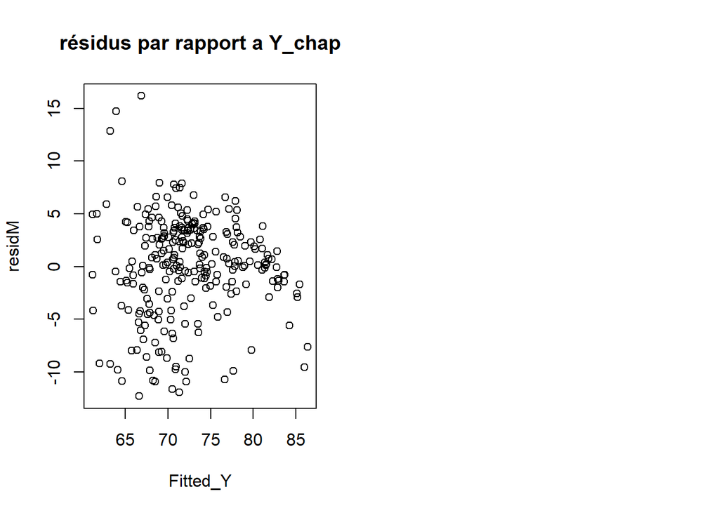

Le graphique des résidus du modele par rapport à l’estimateur de l’espérance de vie en 2018 est un nuage de points aléatoire. Ce qui confirme notre cas d’homoscédasticité.